# HW 5_1 - Tim Demetriades

## Compare the different compiler setups

10/3/2021

First the **imdb dataset** from keras is imported and the training and testing data and labels are loaded.

```python
from keras.datasets import imdb
(train_data, train_labels),(test_data, test_labels) = imdb.load_data( num_words=10000)
```

We display some of the loaded data.

```python
train_data.shape
```

```
(25000,)
```

```python
train_data[0][0:10]
```

```
[1, 14, 22, 16, 43, 530, 973, 1622, 1385, 65]
```

```python
train_labels[0:20]
```

```
array([1, 0, 0, 1, 0, 0, 1, 0, 1, 0, 1, 0, 0, 0, 0, 0, 1, 1, 0, 1],
      dtype=int64)
```

Here numpy is imported and a function is created to vectorize a sequence. First a numpy array that has rows=len(sequence) and column=dimension (10,000 by default) is initialized with 0s. Then for every element in the array we enumerate through them and set certain elements to 1 (while the rest remain 0).

```python
import numpy as np
def vectorize_sequences(sequences, dimension=10000):
    results = np.zeros((len(sequences), dimension))
    for i, sequence in enumerate(sequences):
        results[i, sequence] = 1.
    return results
```

The train_data and test_data are vectorized.

```python
x_train = vectorize_sequences(train_data)
x_test = vectorize_sequences(test_data)
```

Here's what the vectorized data looks like.

```python
print(x_train.shape)
print(x_test.shape)

print(x_train[0][0:20])
print(x_test[0][0:20])
```

```
(25000, 10000)
(25000, 10000)
[0. 1. 1. 0. 1. 1. 1. 1. 1. 1. 0. 0. 1. 1. 1. 1. 1. 1. 1. 1.]
[0. 1. 1. 0. 1. 1. 1. 1. 1. 1. 1. 0. 0. 1. 1. 0. 1. 0. 0. 0.]
```

```python
y_train = np.asarray(train_labels).astype('float32')
y_test = np.asarray(test_labels).astype('float32')
```

```python
print(train_labels.shape)
train_labels
```

```
(25000,)
```

```
array([1, 0, 0, ..., 0, 1, 0], dtype=int64)
```

```python
print(y_train.shape)
y_train
```

```
(25000,)
```

```
array([1., 0., 0., ..., 0., 1., 0.], dtype=float32)
```

Next the models and layers classes from the keras module are imported. We create a **sequential model**. **3 dense layers (1 hidden layer)** are added with 16, 16, and 1 dimensionality of the output space (number of **neurons**) respectively. The first 2 use **relu activate functions** while the last uses a **sigmoid**. The first layer has an **input shape of 10,000**.

```python
from keras import models
from keras import layers
model = models.Sequential()
model.add(layers.Dense(16, activation='relu', input_shape=(10000,)))
model.add(layers.Dense(16, activation='relu'))
model.add(layers.Dense(1, activation='sigmoid'))
```

```python
model
```

```
<keras.engine.sequential.Sequential at 0x1b4cb07c400>
```

```python
len(model.layers)
```

```
3
```

The model is configured for training. It uses an **rmsprop optimizer** that uses the RMSprop algorithm. It uses the **binary crossentropy loss function**. The **accuracy metric** is set to be evauluated during training and testing.

```python
model.compile(optimizer='rmsprop',
              loss='binary_crossentropy',
              metrics=['accuracy'])
```

The model is configured for training, except now the RMSprop optimizer is imported and uses a **learning rate of 0.001**.

```python
from tensorflow.keras import optimizers
model.compile(optimizer=optimizers.RMSprop(learning_rate=0.001),
              loss='binary_crossentropy',
              metrics=['accuracy'])
```

The model is configured for training like above, except now the **binary metric** is set to be evaluated during training and testing.

```python
from tensorflow.keras import losses
from tensorflow.keras import metrics

model.compile(optimizer=optimizers.RMSprop(learning_rate=0.001),
              loss=losses.binary_crossentropy,
              metrics=[metrics.binary_accuracy])
```

Here we partition the dataset. The **first 10,000** of 25,000 elements of x_train are taken and set to x_val for testing/validation and the other **15,000** are set to partial_x_train for training. The same is done for y_train.

```python
x_val = x_train[:10000]
partial_x_train = x_train[10000:]
y_val = y_train[:10000]
partial_y_train = y_train[10000:]
```

```python
x_train.shape
```

```
(25000, 10000)
```

```python
x_val.shape
```

```
(10000, 10000)
```

```python
partial_x_train.shape
```

```
(15000, 10000)
```

The model is configured for training. It is then **trained** with **partial_x_train as the input data** and **partial_y_train as the target data**. **20 epochs** (iterations) are used, the **batch size (number of samples per gradient update) is set to 512**, and **validation data is set to x_val and y_val**.

```python
model.compile(optimizer='rmsprop',
              loss='binary_crossentropy',
              metrics=['acc'])

history = model.fit(partial_x_train,
                    partial_y_train,
                    epochs=20,
                    batch_size=512,
                    validation_data=(x_val, y_val))
```

We create a dictionary of the history for the loss, accuracy, validation loss, and validation accuracy.

```python
history_dict = history.history
history_dict.keys()
```

```
dict_keys(['loss', 'acc', 'val_loss', 'val_acc'])
```

The history dictionary is then plotted in two graphs, one for the loss and another for the accuracy.

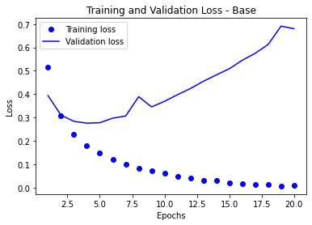

```python
import matplotlib.pyplot as plt
loss_values = history_dict['loss']
acc_values = history_dict['acc']
val_loss_values = history_dict['val_loss']
epochs = range(1, len(acc_values) + 1)
plt.plot(epochs, loss_values, 'bo', label='Training loss')
plt.plot(epochs, val_loss_values, 'b', label='Validation loss')
plt.title('Training and Validation Loss - Base')
plt.xlabel('Epochs')
plt.ylabel('Loss')
plt.legend()
plt.show()
```

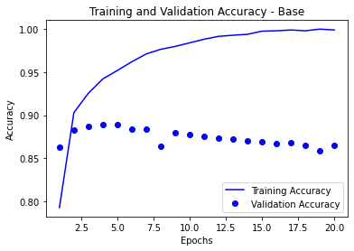

```python
# Plotting Accuracy
acc_values = history_dict['acc']
val_acc_values = history_dict['val_acc']
epochs = range(1, len(acc_values) + 1)
plt.plot(epochs, acc_values, 'b', label='Training Accuracy')
plt.plot(epochs, val_acc_values, 'bo', label='Validation Accuracy')
plt.title('Training and Validation Accuracy - Base')
plt.xlabel('Epochs')
plt.ylabel('Accuracy')
plt.legend()
plt.show()
```

```python
print(f'Training Loss: {round(loss_values[-1], 4)}')
print(f'Testing Loss: {round(val_loss_values[-1], 4)}')
print(f'Training Accuracy: {round(acc_values[-1], 4)}')
print(f'Testing Accuracy: {round(val_acc_values[-1], 4)}')
```

```
Training Loss: 0.0085
Testing Loss: 0.6799
Training Accuracy: 0.9987
Testing Accuracy: 0.8646
```

Above you can see the training loss decreases significantly over the epochs, but the validation loss decreases slightly before increasing. This can be a sign over **overfitting**, as the model fits nicely with the training data but not very well with the validation data. This means it **may not be generalized to new data**.

We can try a couple of different things to improve the model. First, let's adjust the number of hidden layers.

### Adding One More Hidden Layer (2 Hidden Layers)

```python
model = models.Sequential()
model.add(layers.Dense(16, activation='relu', input_shape=(10000,)))
model.add(layers.Dense(16, activation='relu'))
model.add(layers.Dense(16, activation='relu'))
model.add(layers.Dense(1, activation='sigmoid'))

model.compile(optimizer='rmsprop',
              loss='binary_crossentropy',
              metrics=['acc'])

history = model.fit(partial_x_train,
                    partial_y_train,
                    epochs=20,
                    batch_size=512,
                    validation_data=(x_val, y_val),
                    verbose=0)
```

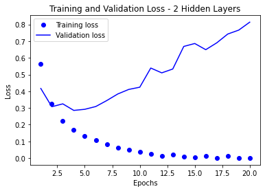

```python
history_dict = history.history

# Plotting Loss
loss_values = history_dict['loss']
acc_values = history_dict['acc']
val_loss_values = history_dict['val_loss']
epochs = range(1, len(acc_values) + 1)
plt.plot(epochs, loss_values, 'bo', label='Training loss')
plt.plot(epochs, val_loss_values, 'b', label='Validation loss')
plt.title('Training and Validation Loss - 2 Hidden Layers')
plt.xlabel('Epochs')
plt.ylabel('Loss')
plt.legend()
plt.show()
```

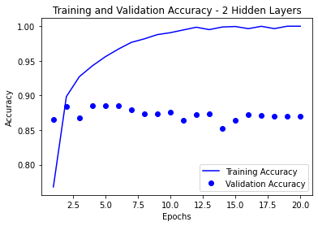

```python
# Plotting Accuracy
acc_values = history_dict['acc']
val_acc_values = history_dict['val_acc']
epochs = range(1, len(acc_values) + 1)
plt.plot(epochs, acc_values, 'b', label='Training Accuracy')
plt.plot(epochs, val_acc_values, 'bo', label='Validation Accuracy')
plt.title('Training and Validation Accuracy - 2 Hidden Layers')
plt.xlabel('Epochs')
plt.ylabel('Accuracy')
plt.legend()
plt.show()
```

```python
print(f'Training Loss: {round(loss_values[-1], 4)}')
print(f'Testing Loss: {round(val_loss_values[-1], 4)}')
print(f'Training Accuracy: {round(acc_values[-1], 4)}')
print(f'Testing Accuracy: {round(val_acc_values[-1], 4)}')
```

```
Training Loss: 0.0007
Testing Loss: 0.8138
Training Accuracy: 1.0
Testing Accuracy: 0.8695
```

## Removing a Hidden Layer (0 Hidden Layers)

```python
model = models.Sequential()
model.add(layers.Dense(16, activation='relu', input_shape=(10000,)))
model.add(layers.Dense(1, activation='sigmoid'))

model.compile(optimizer='rmsprop',
              loss='binary_crossentropy',
              metrics=['acc'])

history = model.fit(partial_x_train,
                    partial_y_train,
                    epochs=20,
                    batch_size=512,
                    validation_data=(x_val, y_val),
                    verbose=0)
```

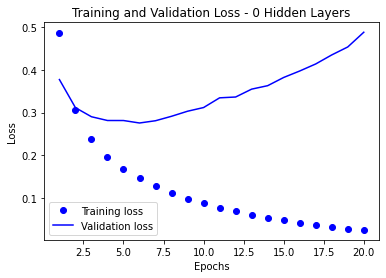

```python
history_dict = history.history

# Plotting Loss
loss_values = history_dict['loss']
acc_values = history_dict['acc']
val_loss_values = history_dict['val_loss']
epochs = range(1, len(acc_values) + 1)
plt.plot(epochs, loss_values, 'bo', label='Training loss')
plt.plot(epochs, val_loss_values, 'b', label='Validation loss')
plt.title('Training and Validation Loss - 0 Hidden Layers')
plt.xlabel('Epochs')
plt.ylabel('Loss')
plt.legend()
plt.show()
```

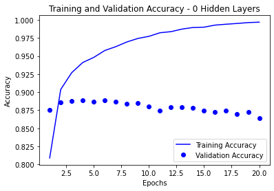

```python
# Plotting Accuracy
acc_values = history_dict['acc']
val_acc_values = history_dict['val_acc']
epochs = range(1, len(acc_values) + 1)
plt.plot(epochs, acc_values, 'b', label='Training Accuracy')
plt.plot(epochs, val_acc_values, 'bo', label='Validation Accuracy')
plt.title('Training and Validation Accuracy - 0 Hidden Layers')
plt.xlabel('Epochs')
plt.ylabel('Accuracy')
plt.legend()
plt.show()
```

```python
print(f'Training Loss: {round(loss_values[-1], 4)}')
print(f'Testing Loss: {round(val_loss_values[-1], 4)}')
print(f'Training Accuracy: {round(acc_values[-1], 4)}')
print(f'Testing Accuracy: {round(val_acc_values[-1], 4)}')
```

```
Training Loss: 0.0254
Testing Loss: 0.4881
Training Accuracy: 0.9969
Testing Accuracy: 0.8645
```

Using 0, 1, or 2 hidden layers seems to produce similar results in terms of both accuracy and loss. Of the 3, the one with the most **(2) hidden layers** seems to have performed the best by a small margin. Interestingly, the model with 0 hidden layers has the lowest validation loss, which might mean it is more general than the others and as a result not as overfit.

Let's take the base model again and this time adjust the number of hidden units (neurons). The base model uses 16 neurons. Let's try 32 and 64 neurons.

## Increasing Hidden Neurons to 32

```python
model = models.Sequential()
model.add(layers.Dense(16, activation='relu', input_shape=(10000,)))
model.add(layers.Dense(32, activation='relu'))
model.add(layers.Dense(1, activation='sigmoid'))

model.compile(optimizer='rmsprop',
              loss='binary_crossentropy',
              metrics=['acc'])

history = model.fit(partial_x_train,
                    partial_y_train,
                    epochs=20,
                    batch_size=512,
                    validation_data=(x_val, y_val),
                    verbose=0)
```

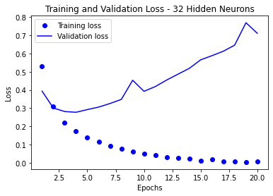

```python
history_dict = history.history

# Plotting Loss
loss_values = history_dict['loss']
acc_values = history_dict['acc']
val_loss_values = history_dict['val_loss']
epochs = range(1, len(acc_values) + 1)
plt.plot(epochs, loss_values, 'bo', label='Training loss')
plt.plot(epochs, val_loss_values, 'b', label='Validation loss')
plt.title('Training and Validation Loss - 32 Hidden Neurons')
plt.xlabel('Epochs')
plt.ylabel('Loss')
plt.legend()
plt.show()
```

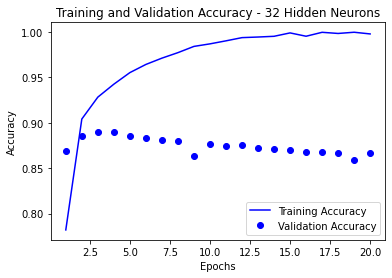

```python
# Plotting Accuracy
acc_values = history_dict['acc']
val_acc_values = history_dict['val_acc']
epochs = range(1, len(acc_values) + 1)
plt.plot(epochs, acc_values, 'b', label='Training Accuracy')
plt.plot(epochs, val_acc_values, 'bo', label='Validation Accuracy')
plt.title('Training and Validation Accuracy - 32 Hidden Neurons')
plt.xlabel('Epochs')
plt.ylabel('Accuracy')
plt.legend()
plt.show()
```

```python
print(f'Training Loss: {round(loss_values[-1], 4)}')
print(f'Testing Loss: {round(val_loss_values[-1], 4)}')
print(f'Training Accuracy: {round(acc_values[-1], 4)}')
print(f'Testing Accuracy: {round(val_acc_values[-1], 4)}')
```

```
Training Loss: 0.0081
Testing Loss: 0.7113
Training Accuracy: 0.9979
Testing Accuracy: 0.8672
```

## Increasing Hidden Neurons to 64

```python
model = models.Sequential()
model.add(layers.Dense(16, activation='relu', input_shape=(10000,)))
model.add(layers.Dense(64, activation='relu'))
model.add(layers.Dense(1, activation='sigmoid'))

model.compile(optimizer='rmsprop',
              loss='binary_crossentropy',
              metrics=['acc'])

history = model.fit(partial_x_train,
                    partial_y_train,
                    epochs=20,
                    batch_size=512,
                    validation_data=(x_val, y_val),
                    verbose=0)
```

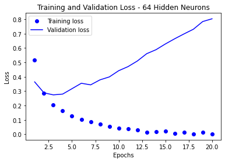

```python
history_dict = history.history

# Plotting Loss
loss_values = history_dict['loss']
acc_values = history_dict['acc']
val_loss_values = history_dict['val_loss']
epochs = range(1, len(acc_values) + 1)
plt.plot(epochs, loss_values, 'bo', label='Training loss')
plt.plot(epochs, val_loss_values, 'b', label='Validation loss')
plt.title('Training and Validation Loss - 64 Hidden Neurons')
plt.xlabel('Epochs')
plt.ylabel('Loss')
plt.legend()
plt.show()
```

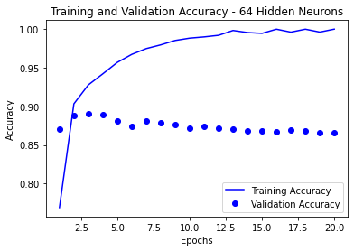

```python
# Plotting Accuracy
acc_values = history_dict['acc']
val_acc_values = history_dict['val_acc']
epochs = range(1, len(acc_values) + 1)
plt.plot(epochs, acc_values, 'b', label='Training Accuracy')
plt.plot(epochs, val_acc_values, 'bo', label='Validation Accuracy')
plt.title('Training and Validation Accuracy - 64 Hidden Neurons')
plt.xlabel('Epochs')
plt.ylabel('Accuracy')
plt.legend()
plt.show()
```

```python
print(f'Training Loss: {round(loss_values[-1], 4)}')
print(f'Testing Loss: {round(val_loss_values[-1], 4)}')
print(f'Training Accuracy: {round(acc_values[-1], 4)}')
print(f'Testing Accuracy: {round(val_acc_values[-1], 4)}')
```

```
Training Loss: 0.0016
Testing Loss: 0.8036
Training Accuracy: 0.9999
Testing Accuracy: 0.8653
```

Looking at these graphs, it seems the model that uses **32 Hidden Neurons** produces the best results. There is a fine balance when choosing the number of neurons, as too many neurons can overcomplicate the model but not enough neurons can make the model too general.

Let's trying changing the loss function now. The base model uses binary cross entropy, let's see what happens when we switch to mse.

## Changing Loss Function to MSE

```python
model = models.Sequential()
model.add(layers.Dense(16, activation='relu', input_shape=(10000,)))
model.add(layers.Dense(16, activation='relu'))
model.add(layers.Dense(1, activation='sigmoid'))

model.compile(optimizer='rmsprop',
              loss='mse',
              metrics=['acc'])

history = model.fit(partial_x_train,
                    partial_y_train,
                    epochs=20,
                    batch_size=512,
                    validation_data=(x_val, y_val),
                    verbose=0)
```

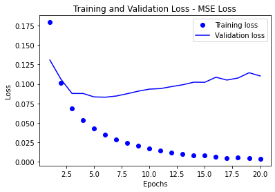

```python
history_dict = history.history

# Plotting Loss
loss_values = history_dict['loss']
acc_values = history_dict['acc']
val_loss_values = history_dict['val_loss']
epochs = range(1, len(acc_values) + 1)
plt.plot(epochs, loss_values, 'bo', label='Training loss')
plt.plot(epochs, val_loss_values, 'b', label='Validation loss')
plt.title('Training and Validation Loss - MSE Loss')
plt.xlabel('Epochs')
plt.ylabel('Loss')
plt.legend()
plt.show()
```

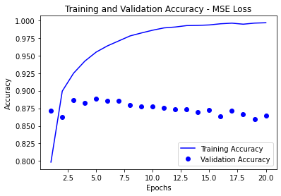

```python
# Plotting Accuracy
acc_values = history_dict['acc']
val_acc_values = history_dict['val_acc']
epochs = range(1, len(acc_values) + 1)
plt.plot(epochs, acc_values, 'b', label='Training Accuracy')
plt.plot(epochs, val_acc_values, 'bo', label='Validation Accuracy')
plt.title('Training and Validation Accuracy - MSE Loss')
plt.xlabel('Epochs')
plt.ylabel('Accuracy')
plt.legend()
plt.show()
```

```python
print(f'Training Loss: {round(loss_values[-1], 4)}')
print(f'Testing Loss: {round(val_loss_values[-1], 4)}')
print(f'Training Accuracy: {round(acc_values[-1], 4)}')
print(f'Testing Accuracy: {round(val_acc_values[-1], 4)}')
```

```
Training Loss: 0.0037
Testing Loss: 0.1103
Training Accuracy: 0.9967
Testing Accuracy: 0.8649
```

Changing the loss function from Binary Cross Entropy to **MSE** (Mean Squared Error) seems to have produced **better results**. Now, the validation loss does not increase so drastically after around the 7th epoch compared to when using Binary Cross Entropy loss. It is important to note thought that even though the loss is much lower, this is also a different loss function that is calculating loss in a different way.

Finally, let's see what happens to the base model if instead of using the relu activation function we use the tanh activation function. Below are what the two functions look like.

## Changing Activation Function to Tanh

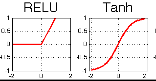

```python
model = models.Sequential()
model.add(layers.Dense(16, activation='tanh', input_shape=(10000,)))
model.add(layers.Dense(16, activation='tanh'))
model.add(layers.Dense(1, activation='sigmoid'))

model.compile(optimizer='rmsprop',
              loss='binary_crossentropy',
              metrics=['acc'])

history = model.fit(partial_x_train,
                    partial_y_train,
                    epochs=20,
                    batch_size=512,
                    validation_data=(x_val, y_val),
                    verbose=0)
```

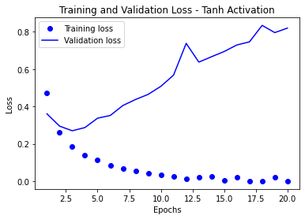

```python
history_dict = history.history

# Plotting Loss
loss_values = history_dict['loss']
acc_values = history_dict['acc']
val_loss_values = history_dict['val_loss']
epochs = range(1, len(acc_values) + 1)
plt.plot(epochs, loss_values, 'bo', label='Training loss')
plt.plot(epochs, val_loss_values, 'b', label='Validation loss')
plt.title('Training and Validation Loss - Tanh Activation')
plt.xlabel('Epochs')
plt.ylabel('Loss')
plt.legend()
plt.show()
```

[figure not shown]

```python
# Plotting Accuracy
acc_values = history_dict['acc']
val_acc_values = history_dict['val_acc']
epochs = range(1, len(acc_values) + 1)
plt.plot(epochs, acc_values, 'b', label='Training Accuracy')
plt.plot(epochs, val_acc_values, 'bo', label='Validation Accuracy')
plt.title('Training and Validation Accuracy - MSE Loss')
plt.xlabel('Epochs')
plt.ylabel('Accuracy')
plt.legend()
plt.show()
```

```python
print(f'Training Loss: {round(loss_values[-1], 4)}')
print(f'Testing Loss: {round(val_loss_values[-1], 4)}')
print(f'Training Accuracy: {round(acc_values[-1], 4)}')
print(f'Testing Accuracy: {round(val_acc_values[-1], 4)}')
```

```
Training Loss: 0.0006
Testing Loss: 0.8202
Training Accuracy: 1.0
Testing Accuracy: 0.8595
```

Overall, adjusting the hyperparameters of the model such as the number of hidden layers, the number of neurons in each layer, etc. can alter the performance of the model. Although the changes we made only made slight improvements (with some also making the model slightly worse), overall the model still had a tendency to perform much worse on the test data, indicating further changes that need to be made to prevent overfitting. One option is combining multiple of the thing we tried, such as adding more hidden layers and increasing the number of neurons. There is still a fine balance that needs to be found to get the best model.